# Controlling the axes

In `ggplot` we can adapt any element of a plot. Very often we will like to modify the limits of the x and y axis, the labels or the markers and ticks. There are different functions to set axis limits :

- `xlim()` and `ylim()`
- `expand_limits()`
- `scale_x_continuous()` and `scale_y_continuous()`

# Setting the limits of an axis

There are several ways in which we can redefine the limits of a plot. This will allow us to *zoom* into specific sections of a plot or just enhance the message. There are several ways to do so:

We can pass a vector with the limits to either `xlim()` or `ylim()`:

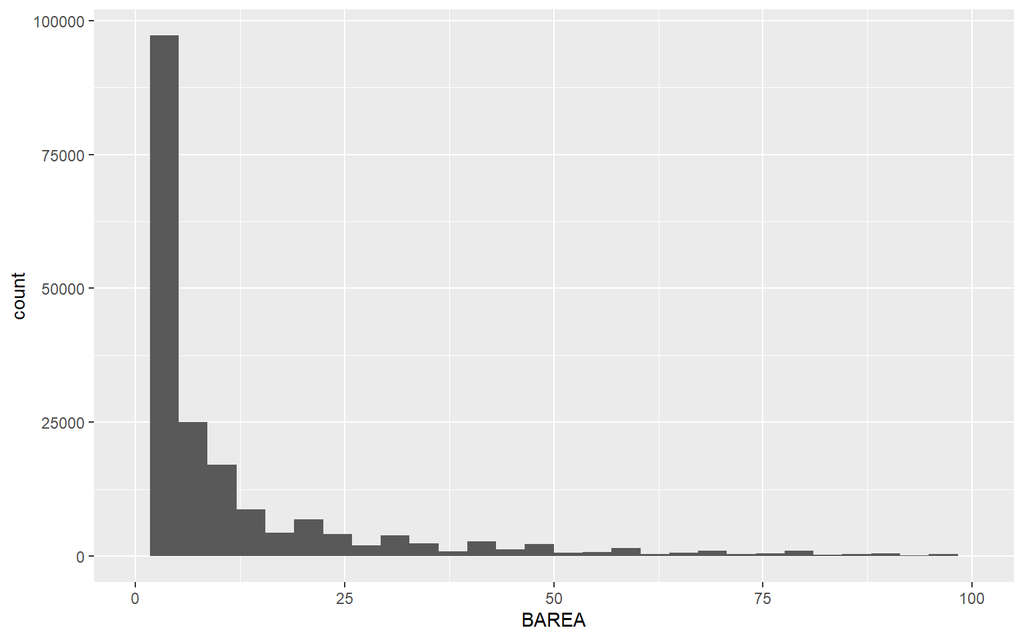

```r
fires %>%
  group_by(CAUSE,MONTH) %>%
    ggplot(aes(x=BAREA)) +
      geom_histogram() +
      xlim(c(0,100))
```

> Note that we are not filtering out records outside the limits but rather not showing them

The alternative is using `scale_x_continuous()` and `scale_y_continuous()`, and define the limits inside. But let’s take a closer look into this functions and what functionalities they provide.

# Use scale_xx() functions

The `scale` functions (`scale_x_continous` and so on) are perhaps the most flexible way to manipulate axis since they bring in several utilities like:

- `name` : x or y axis labels
- `breaks` : to control the breaks in the guide (axis ticks, grid lines, .). Among the possible values, there are:
  - `NULL` : hide all breaks
- `waiver()` : the default break computation
- a *character or numeric vector* specifying the breaks to display
- `labels` : labels of axis tick marks. Allowed values are :
  - NULL for no labels
- waiver() for the default labels
- character vector to be used for break labels
- limits: a numeric vector specifying x or y axis limits (min, max)
- `trans` for axis transformations. Possible values are “log2”, “log10”, “sqrt2”…

## Setting the limits

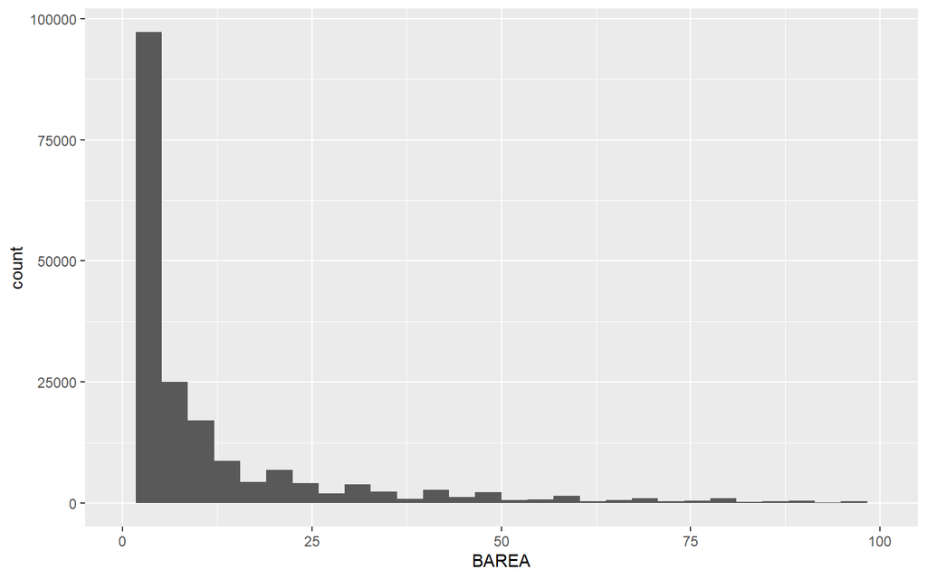

```r
fires %>%
  group_by(CAUSE,MONTH) %>%
    ggplot(aes(x=BAREA)) +
      geom_histogram() +
      scale_x_continuous(limits=c(0,100))
```

## Axis transformations

We have seen how to transform a variable *on the fly* when applying `log()` to `BAREA`. That’s an option, but we can apply the transformation on the axes instead with `trans`.

We can transform and show transformed values on the axis:

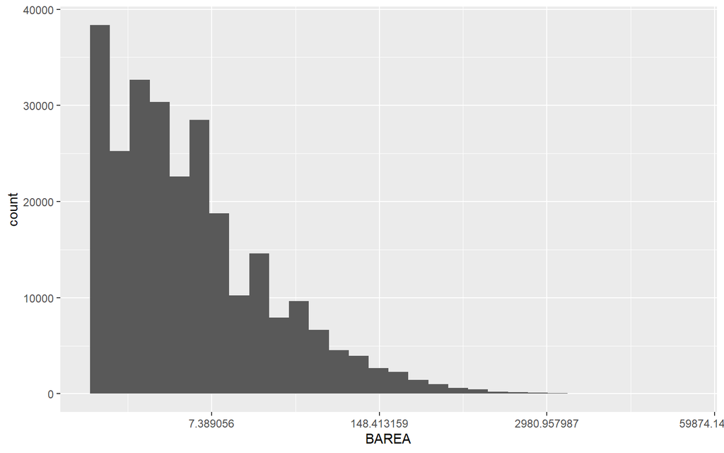

```r
fires %>%
  group_by(CAUSE,MONTH) %>%
    ggplot(aes(x=BAREA)) +
      geom_histogram() +
      scale_x_continuous(trans='log')
```

Or transform and keep the original values:

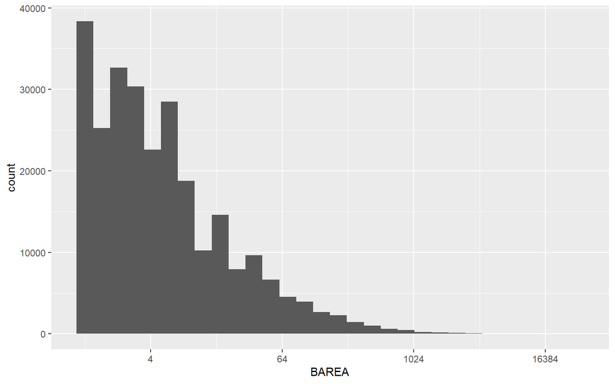

```r
fires %>%
  group_by(CAUSE,MONTH) %>%
    ggplot(aes(x=BAREA)) +
      geom_histogram() +
      scale_x_continuous(trans='log2')
```

# Axis labels and ticks

Something in what might be interseted is in changing the position or labels of axis ticks. The `breaks` and `labels` options let us change the position and text of axis ticks, respectively.

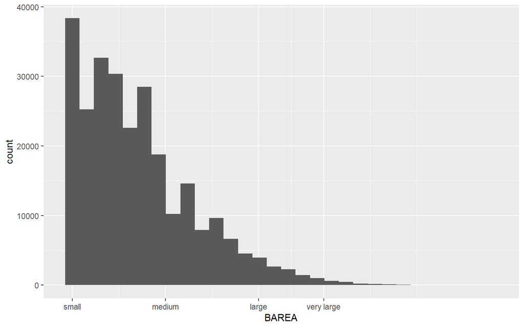

```r
fires %>%
  group_by(CAUSE,MONTH) %>%
    ggplot(aes(x=BAREA)) +
      geom_histogram() +
      scale_x_continuous(trans='log2',
        breaks = c(1,10,100,500),
                         labels = c('small','medium', 'large','very large'))
```